# Statistical Analysis

25/10/2019

## Introduction

- All these data sets are made up of data from the US government.
- Data resourse:https://www.kaggle.com/fernandol/countries-of-the-world/download

## Background Information.

- Generally,Child mortality is regarded as one of the best measures of the health status of a country.
- Over the years,some research reveals that income is an important determinant of child survival.

## Problem Statement

- The investigation is mainly about exploring the relationship between GDP and infant mortality for a country,whether it is stasticlly significant follow a linear relation or independent. -pearson correlation coefficient model and Linear regression model is applied to reject or accept the problem statement.

## Data Cont.

- The data set is collected by the US Government in 2018 including data on population,region,area size,infant mortality and more.
- Important variables –mortality :Infant mortality per 1000 birth. –GDP:Gross Domestic Product in $ per capita. -The data set is filtered into a smaller one by the variables we are interested in.

```r
Country <- read_csv("D:/intro to stastics/assignment3/countries of the world.csv")
C<-dplyr::select(Country,`GDP ($ per capita)`,
                 `Infant mortality (per 1000 births)`)
```

## Descriptive Statistics

- The Infant mortality and GDP variables are summarised and scanned.

–Infant mortality:

```r
C%>%summarise(Min = min(`Infant mortality (per 1000 births)`,na.rm = TRUE),
              Q1 = quantile(`Infant mortality (per 1000 births)`,probs = .25,na.rm = TRUE),
              Median = median(`Infant mortality (per 1000 births)`, na.rm = TRUE),
              Q3 = quantile(`Infant mortality (per 1000 births)`,probs = .75,na.rm = TRUE),
              Max = max(`Infant mortality (per 1000 births)`,na.rm = TRUE),
              Mean = mean(`Infant mortality (per 1000 births)`, na.rm = TRUE),
              SD = sd(`Infant mortality (per 1000 births)`, na.rm = TRUE),
              n = n(),
              Missing = sum(is.na(`Infant mortality (per 1000 births)`)))
```

```
## # A tibble: 1 x 9
##     Min    Q1 Median    Q3   Max  Mean    SD     n Missing
##   <dbl> <dbl>  <dbl> <dbl> <dbl> <dbl> <dbl> <int>   <int>
## 1    19  631.   1731 4930. 19119 3165. 3501.   227       3
```

–GDP:

```r
C%>%summarise(Min = min(`GDP ($ per capita)`,na.rm = TRUE),
              Q1 = quantile(`GDP ($ per capita)`,probs = .25,na.rm = TRUE),
              Median = median(`GDP ($ per capita)`, na.rm = TRUE),
              Q3 = quantile(`GDP ($ per capita)`,probs = .75,na.rm = TRUE),
              Max = max(`GDP ($ per capita)`,na.rm = TRUE),
              Mean = mean(`GDP ($ per capita)`, na.rm = TRUE),
              SD = sd(`GDP ($ per capita)`, na.rm = TRUE),
              n = n(),
              Missing = sum(is.na(`GDP ($ per capita)`)))
```

```
## # A tibble: 1 x 9
##     Min    Q1 Median    Q3   Max  Mean     SD     n Missing
##   <dbl> <dbl>  <dbl> <dbl> <dbl> <dbl>  <dbl> <int>   <int>
## 1   500  1900   5550 15700 55100 9690. 10049.   227       1
```

There are 3 and 1 missing values in the two variable respectively,due to the sample size 227 I simply exclude them.

```r
C<-C[complete.cases(C),]
```

## visualisation

- The two important variables are scanned to find any outliners.

Infant mortality:

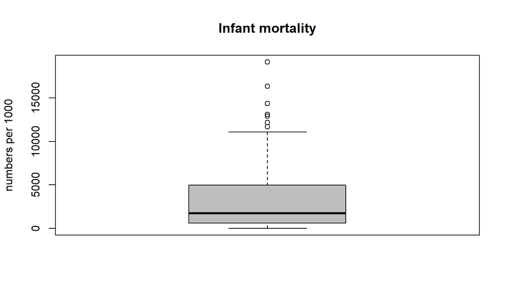

```r
boxplot(C$`Infant mortality (per 1000 births)`, main = "Infant mortality", ylab = "numbers per 1000", col = "grey")
```

GDP:

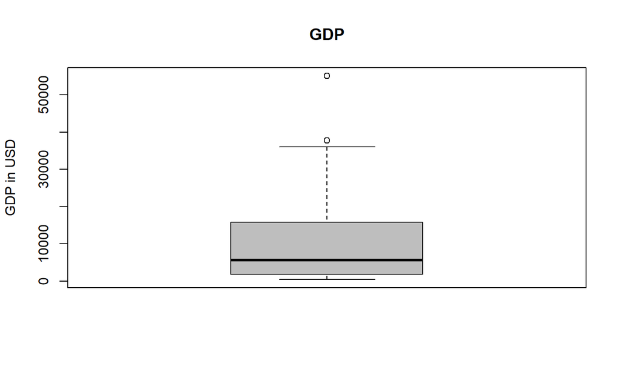

```r
boxplot(C$`GDP ($ per capita)`, main = "GDP", ylab = "GDP in USD", col = "grey")
```

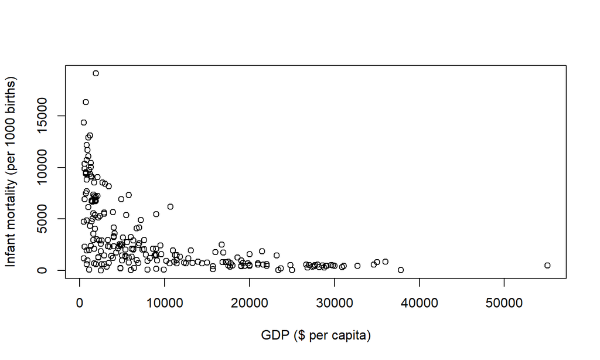

```r
plot(`Infant mortality (per 1000 births)`~`GDP ($ per capita)`,data=C)
```

## Pearson correlation coefficent

The hypothesis test for my investigation is the pearson correlation coeficient(r),and the statistical hypotheses:

\[H_0: r = 0 \]

\[H_A: r \ne 0\]

The correlation between infant mortality and GDP is -0.53 while p value<0.01.Furthermore, the 95% confident intervel[-0.62,-0.43] does not captures H0.Therefore,H0 is rejected.There is a statistically sigificant correlation between infant mortality and GDP.

```r
cor(C$`Infant mortality (per 1000 births)`,C$`GDP ($ per capita)`)
```

```
## [1] -0.5329186
```

```r
b<-as.matrix(dplyr::select(C,`Infant mortality (per 1000 births)`,`GDP ($ per capita)`))
rcorr(b,type="pearson")
```

```
##                                    Infant mortality (per 1000 births)
## Infant mortality (per 1000 births)                               1.00
## GDP ($ per capita)                                              -0.53
##                                    GDP ($ per capita)
## Infant mortality (per 1000 births)              -0.53
## GDP ($ per capita)                               1.00
##
## n= 224
##
##
## P
##                                    Infant mortality (per 1000 births)
## Infant mortality (per 1000 births)
## GDP ($ per capita)                  0
##                                    GDP ($ per capita)
## Infant mortality (per 1000 births)  0
## GDP ($ per capita)
```

```r
r=cor(C$`Infant mortality (per 1000 births)`,C$`GDP ($ per capita)`)
CIr(r=r,n=224,level=.95)
```

```
## [1] -0.6206454 -0.4320149
```

## Linear regression model

The linear regression stastistic hypothesis: \[H_0: r = The data do not fit the linear regression model \]

\[H_A: r \ne The data fit the linear regression model\]

The linear regression equation: \[y=α+βx+ϵ\]

A lm()function is applied to the target variables to see whether it fits the linear regression model.

```r
Clm<-lm(`Infant mortality (per 1000 births)`~`GDP ($ per capita)`,data=C)
Clm%>%summary
```

```
##
## Call:
## lm(formula = `Infant mortality (per 1000 births)` ~ `GDP ($ per capita)`,
##     data = C)
##
## Residuals:
##    Min     1Q Median     3Q    Max
##  -4678  -1905   -657   1250  14504
##
## Coefficients:
##                        Estimate Std. Error t value Pr(>|t|)
## (Intercept)          4966.89434  276.11142  17.989   <2e-16 ***
## `GDP ($ per capita)`   -0.18507    0.01972  -9.384   <2e-16 ***
## ---
## Signif. codes:  0 '***' 0.001 '**' 0.01 '*' 0.05 '.' 0.1 ' ' 1
##
## Residual standard error: 2969 on 222 degrees of freedom
## Multiple R-squared:  0.284,  Adjusted R-squared:  0.2808
## F-statistic: 88.06 on 1 and 222 DF,  p-value: < 2.2e-16
```

The estimate intercept is reported as 4966.89 which is captured at the 0.05 confident intervel(4422.76 to 5511.03).

```r
Clm%>%confint()
```

```
##                             2.5 %       97.5 %
## (Intercept)          4422.7595199 5511.0291631
## `GDP ($ per capita)`   -0.2239408   -0.1462062
```

The F-statistic F(1,222)=88.06,and the p-value is calculated to be far less than 0.01.

```r
pf(q = 88.06,1,222,lower.tail = FALSE)
```

```
## [1] 7.790264e-18
```

The best fit linear relationship:

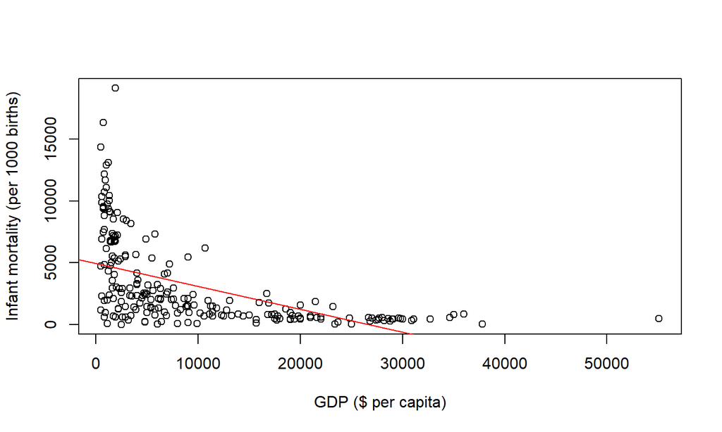

```r
plot(`Infant mortality (per 1000 births)`~`GDP ($ per capita)`,data=C)
abline(Clm,col="red")
```

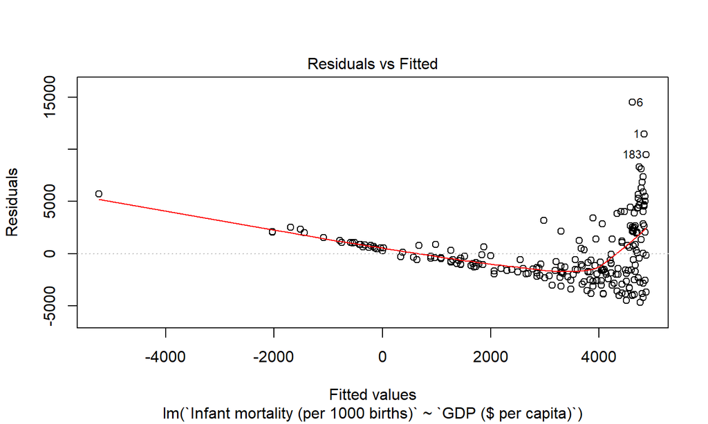

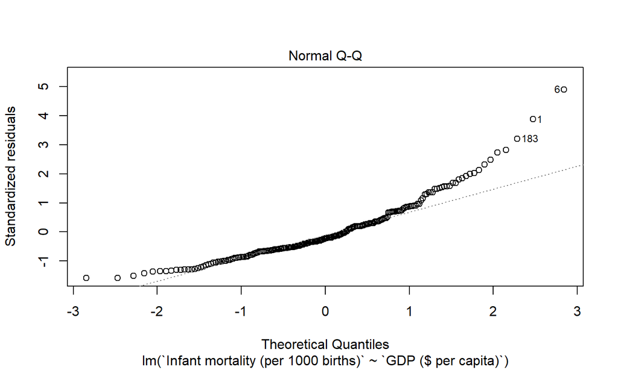

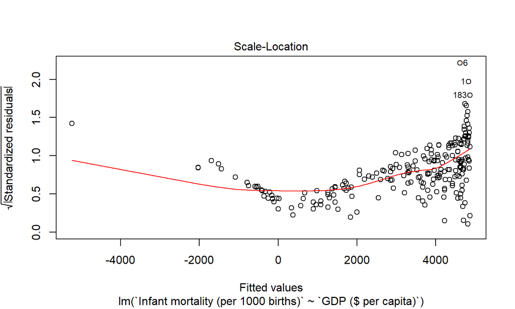

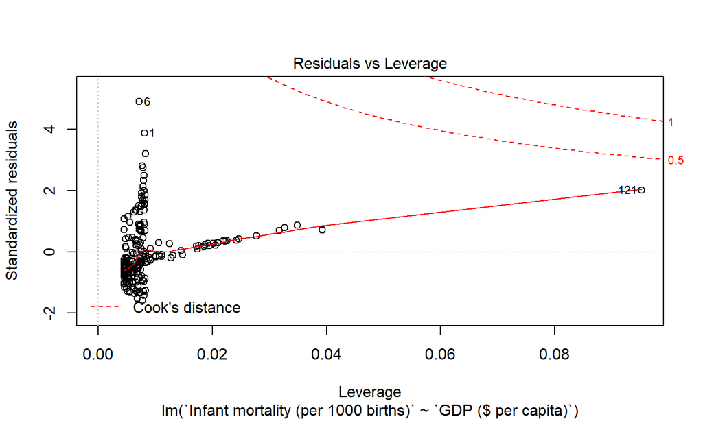

```r
plot(Clm)
```

## References

J R Soc Med.Income and child mortality in developing countries: a systematic review and meta-analysis; 2013 Oct;https://www.ncbi.nlm.nih.gov/pmc/articles/PMC3791093/

Wang L. Health outcomes in low-income countries and policy implications: empirical findings from demographic and health surveys. World Bank Policy Research Working Paper No. 2831. Washington, DC: World Bank; 2002;1–35.